# Lab2

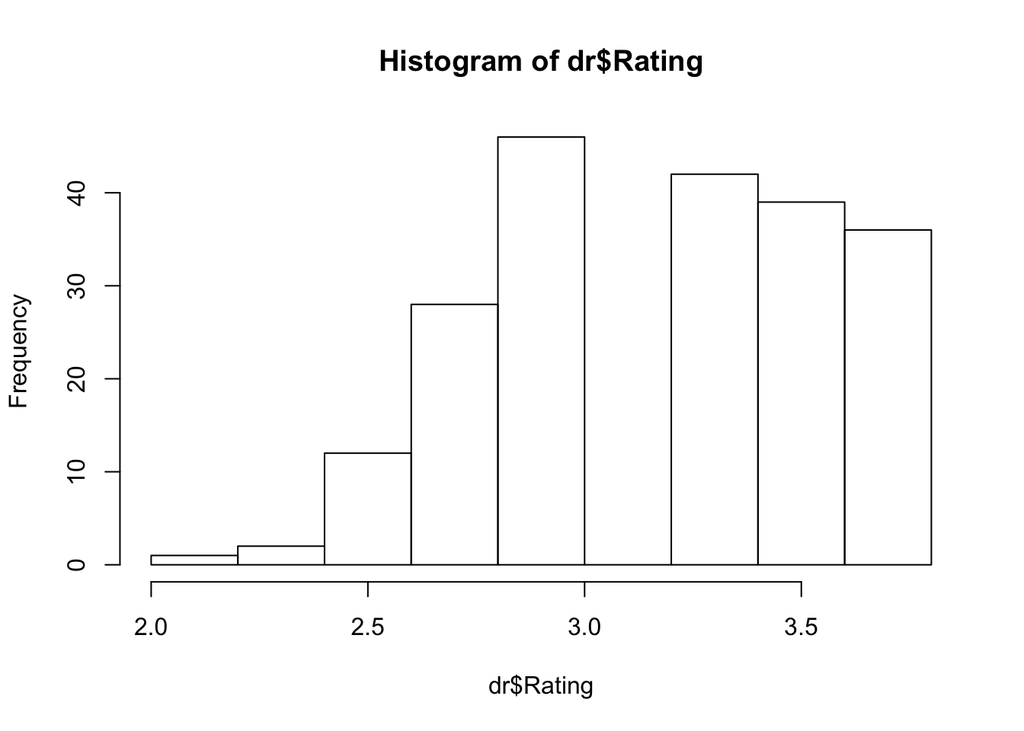

```r
dr<-choco[choco$Bean_Origin=="Dominican Republic", ]
hist(dr$Rating)
```

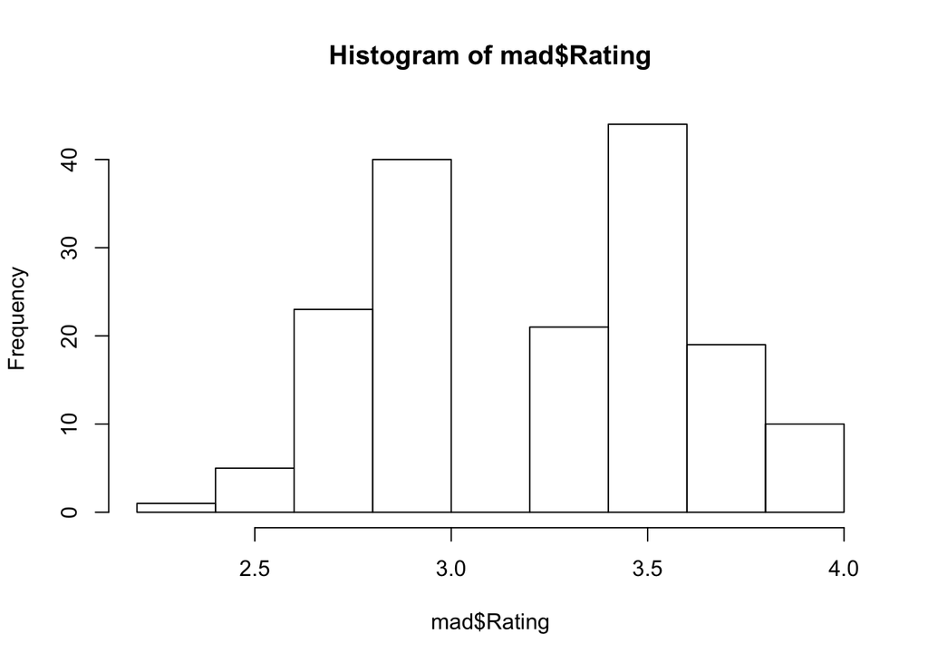

```r
mad<-choco[choco$Bean_Origin=="Madagascar", ]
hist(mad$Rating)
```

```r
mean(venezuela$Rating)
```

```
## [1] 3.22449
```

```r
mean(peru$Rating)
```

```
## [1] 3.165909
```

```r
mean(ecuador$Rating)
```

```
## [1] 3.159198
```

```r
mean(dr$Rating)
```

```
## [1] 3.201942
```

```r
mean(mad$Rating)
```

```
## [1] 3.260736
```

To compare bean origin to rating, I looked at the top five most common countries that beans are from and compared them. The top five countries are Venezuela, Peru, Ecuador, Domincan Republic, and Madigascar. I plotted an individual histogram of each of their ratings and not much could be told from them. They all had a similar curve, which was slightly skewed to the left. What I found particularly interesting was that they mostly were bimodal except for Ecuador. Since not much could be told from the histograms, I looked at the average rating for each country. All of them were very close to each other. I must conclude that depending where the beans are from has little to no effect on the chocolate rating.

## Ingredients (Analysis 2)

```r
head(sort(table(choco$Ingredients), decreasing=TRUE))
```

```
##
##     3- B,S,C       2- B,S   4- B,S,C,L 5- B,S,C,V,L   4- B,S,C,V      2- B,S*
##          885          633          272          184          136           31
```

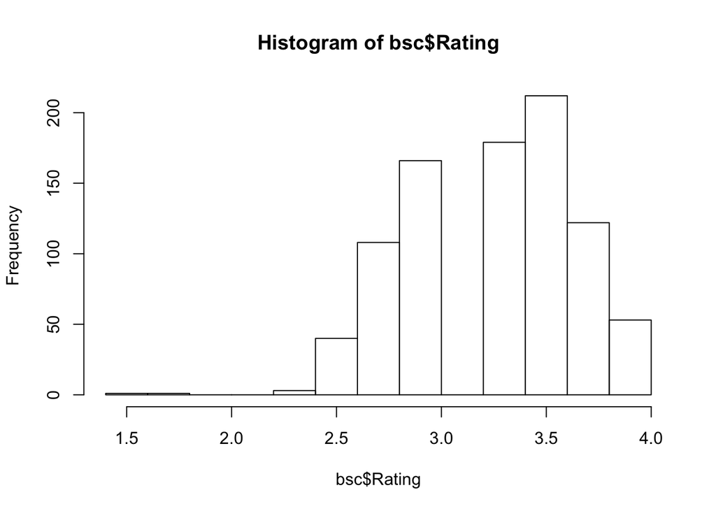

```r
bsc<-choco[choco$Ingredients=="3- B,S,C", ]
hist(bsc$Rating)
```

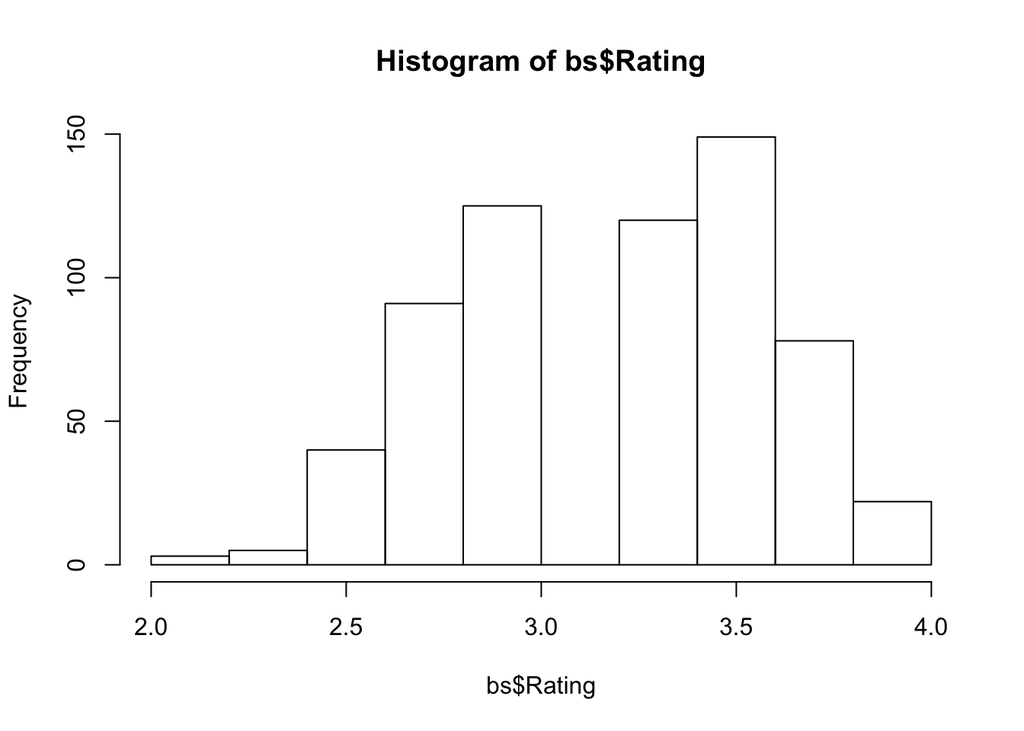

```r
bs<-choco[choco$Ingredients=="2- B,S", ]
hist(bs$Rating)
```

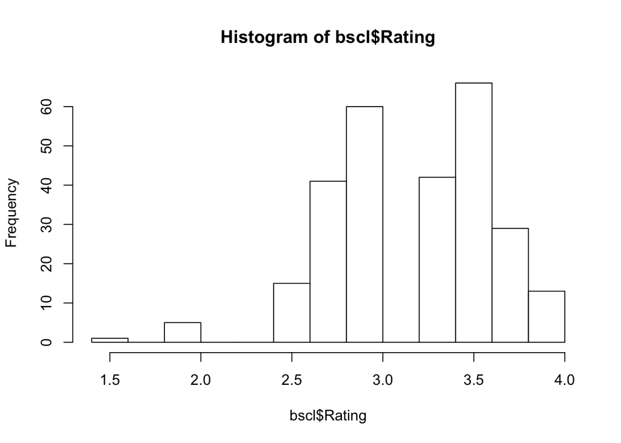

```r
bscl<-choco[choco$Ingredients=="4- B,S,C,L", ]
hist(bscl$Rating)
```